# STADyUM Tutorial: Estimating Transcription Rates from Human CD4+ PRO-seq Data

Xin Zeng

2026/06/02

# Introduction

This tutorial walks through a complete analysis of human CD4+ T cell PRO-seq data using the **STADyUM** package. STADyUM models RNA Polymerase II (Pol II) dynamics by jointly estimating pause release and elongation kinetics from the read distribution across promoter-proximal pause sites and gene bodies.

STADyUM estimates four key parameters per gene:

- **beta (β)**: the pause release rate — how quickly Pol II exits the promoter-proximal paused state. Higher beta means faster pause release.
- **chi (χ)**: a measure of overall transcriptional activity, proportional to both the initiation rate and elongation rate.
- **fkMean (μ)**: the mean elongation time across the gene body, reflecting average Pol II speed.
- **fkSD (σ)**: the standard deviation of elongation time, capturing variability in Pol II speed. Genes fall into two groups — “Sharp” (low σ, homogeneous speed) and “Broad” (high σ, heterogeneous speed).

In this tutorial we will:

1. Load TSS annotations and select one representative TSS per gene.
2. Build promoter-proximal pause and gene body read-counting regions.
3. Run `estimateTranscriptionRates()` to estimate β, χ, μ, and σ.
4. Post-process estimates and classify genes by quantile groups.
5. Visualize relationships among estimated parameters.
6. Relate β to +1 nucleosome occupancy using Micro-C 1D signal.
7. Relate β to promoter histone modification levels (H3K4me3, H3K27ac).

# Setup

## Load Required Libraries

```r
knitr::opts_chunk$set(
  message   = FALSE,
  warning   = FALSE,
  fig.align = "center"
)

library(STADyUM)
library(GenomicRanges)
library(plyranges)
library(dplyr)
library(tidyverse)
library(pracma)          # findpeaks() used in find_valley_threshold()
library(ggpointdensity)
library(cowplot)
library(patchwork)
library(RColorBrewer)
library(genomation)      # ScoreMatrix() for nucleosome signal extraction
library(TxDb.Hsapiens.UCSC.hg38.knownGene)
library(rtracklayer)     # import.bw() for ENCODE bigWig files
library(ggpubr)          # stat_compare_means() for histone boxplots
```

## Configure Paths

All paths are derived from `PROJECT_ROOT`. Set that environment variable — or update `root_dir` — to point to your local copy of the project. `load_config.R` populates `.paths` with the standard sub-directories used throughout the pipeline.

```r
root_dir <- normalizePath(
  Sys.getenv("PROJECT_ROOT", path.expand("~/Desktop/project/YiXin_Likelihood")),
  mustWork = FALSE)
source(file.path(root_dir, "codes", "publish", "load_config.R"))

# Helper functions shared across tutorial sections
source(file.path(root_dir, "codes", "publish", "examples", "helper_function.R"))

# ── Required input files ───────────────────────────────────────────────────────
# TSN: GRanges of detected transcription start sites with PRO-seq signal scores
tsn_file <- file.path(.paths$data, "proseq/tidgrng/PROseq-HUMAN-CD4_tsn.RDS")

# TQ: transcript annotation used to derive 3'-end (TTS) positions
tq_file  <- file.path(.paths$data, "proseq/tq/HUMAN.RDS")

# Stranded PRO-seq bigWig files (5'-end read density at nucleotide resolution)
bw_plus  <- file.path(.paths$data, "proseq/bigwig/p3/PROseq-HUMAN-CD4_plus.bw")
bw_minus <- file.path(.paths$data, "proseq/bigwig/p3/PROseq-HUMAN-CD4_minus.bw")

# ── Optional external files ────────────────────────────────────────────────────
# Micro-C 1D contact signal for +1 nucleosome analysis
ns_signal_file <- file.path(.paths$microc_1d, "human_cd4_1d_signal.bed")

# ENCODE histone modification metadata (produced by the singleCellType pipeline)
histone_meta_file <- file.path(.paths$data, "encode/meta_fc.RDS")

# Flags used to skip optional sections when external files are absent
run_nucleosome <- file.exists(ns_signal_file)
run_histone    <- file.exists(histone_meta_file)

# ── Output directory ───────────────────────────────────────────────────────────
# Only the main STADyUM rate object is saved; intermediate objects are not.
rate_dir <- file.path(.paths$outputs,
                      "publish/singleCellType/1_transcriptionRate/human")
dir.create(rate_dir, recursive = TRUE, showWarnings = FALSE)
```

# Load and Prepare TSS Annotations

## Load the TSN File

The TSN file is a `GRanges` object of detected transcription start sites. Each range is linked to a gene via `ensembl_gene_id`. The `score` column reflects the PRO-seq signal at that position; only sites with score ≥ 5 will be used in downstream region construction.

```r
cd4_tsn <- readRDS(tsn_file)
head(as.data.frame(cd4_tsn)[, c("seqnames", "start", "end", "strand",
                                 "ensembl_gene_id", "score")], 5)
```

```
##   seqnames   start     end strand ensembl_gene_id score
## 1        1  960633  960633      + ENSG00000187961     2
## 2        1  960649  960649      + ENSG00000187961     2
## 3        1  966792  966792      + ENSG00000187583     4
## 4        1 1000905 1000905      + ENSG00000187608     3
## 5        1 1020120 1020120      + ENSG00000188157     3
```

## Select the Most Upstream TSS per Gene

Genes can have multiple annotated TSSs from alternative promoters. We keep only the most upstream TSS per gene to provide a single, unambiguous anchor for each locus. “Most upstream” is defined as the smallest coordinate on the `+` strand and the largest on the `−` strand.

```r
cd4_tsn <- keep_upstream_tss(cd4_tsn)
cat("TSS sites retained:", length(cd4_tsn), "\n")
```

```
## TSS sites retained: 9818
```

# Build Read-Count Regions

STADyUM requires two counting windows per gene:

- **Pause region**: a 200 bp window starting at the TSS, capturing promoter-proximal paused Pol II.
- **Gene body region**: the span from the TSS to the transcription termination site (TTS), trimmed by 2000 bp at each end to exclude the pause peak and 3’-processing signal. Only genes with a trimmed body ≥ 6000 bp are kept.

TSN sites with a PRO-seq score below 5 are excluded as unreliable anchors.

```r
tq     <- readRDS(tq_file)
region <- build_readcount_regions(cd4_tsn, tq@transcripts)

cat("Pause regions:     ", length(region$pause),    "\n")
```

```
## Pause regions:      7868
```

```r
cat("Gene body regions: ", length(region$gene_body), "\n")
```

```
## Gene body regions:  7868
```

# Estimate Transcription Rates

`estimateTranscriptionRates()` counts PRO-seq reads in each pause and gene body window and fits the STADyUM kinetic model. The function returns a `STADyUM` object containing per-gene estimates of β, χ, μ, and σ.

```r
cd4_rate <- estimateTranscriptionRates(
  bw_plus, bw_minus,
  region$pause, region$gene_body,
  "CD4"
)
cat("Genes with rate estimates:", nrow(rates(cd4_rate)), "\n")
```

```
## Genes with rate estimates: 7026
```

# Post-Process Estimated Rates

We add three pieces of metadata to the rates table:

- **betaGroup / fkMeanGroup / chiGroup**: quintile (Q1–Q5) or tertile (Low / Medium / High) labels for each parameter.
- **fkSD**: elongation time standard deviation, computed as $\sigma = \sqrt{\text{fkVar}}$.
- **sdGroup**: Sharp / Broad classification. The fkSD histogram is bimodal; `process_sample_rate()` finds the valley between the two peaks and uses it as the class boundary.

```r
cd4_rate@rates <- process_sample_rate(rates(cd4_rate))
```

## Save STADyUM Output

The estimated rate object is saved as an RDS file. It can be loaded in downstream analyses (between-cell-type comparisons, species comparisons, etc.) without re-running the estimation step.

```r
saveRDS(cd4_rate, file.path(rate_dir, "cd4_rate.RDS"))
cat("Saved:", file.path(rate_dir, "cd4_rate.RDS"), "\n")
```

```
## Saved: /Users/zeng/Desktop/project/YiXin_Likelihood/outputs/publish/singleCellType/1_transcriptionRate/human/cd4_rate.RDS
```

The saved object contains:

- `rates(cd4_rate)`: per-gene data frame with β, χ, μ, σ, and group labels.
- `@pauseRegions`: the 200 bp counting windows used.
- `@counts`: raw pause and gene body read counts.

# Visualize Parameter Relationships

```r
cd4_rate_df <- rates(cd4_rate)
```

## β vs χ

Each point is one gene. β and χ are positively correlated: genes with faster pause release tend to have higher overall transcriptional output, consistent with coupled regulation of promoter pausing and transcription initiation.

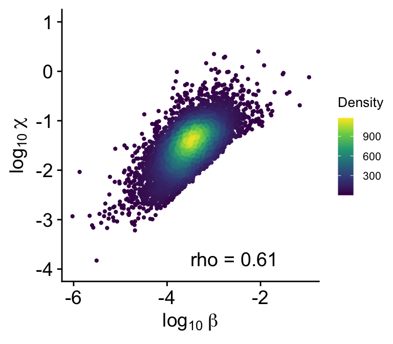

```r
plot_beta_vs_chi(
  cd4_rate_df,
  label_x = -3.5, label_y = -3.8,
  xlim    = c(-6, -1),
  ylim    = c(-4, 1)
)
```

```r
#plot_beta_vs_sigma_density(cd4_rate_df)
```

## μ vs σ

Genes with longer mean elongation times (high μ) tend to have greater elongation-speed variability (high σ), further reflecting the Sharp / Broad structure.

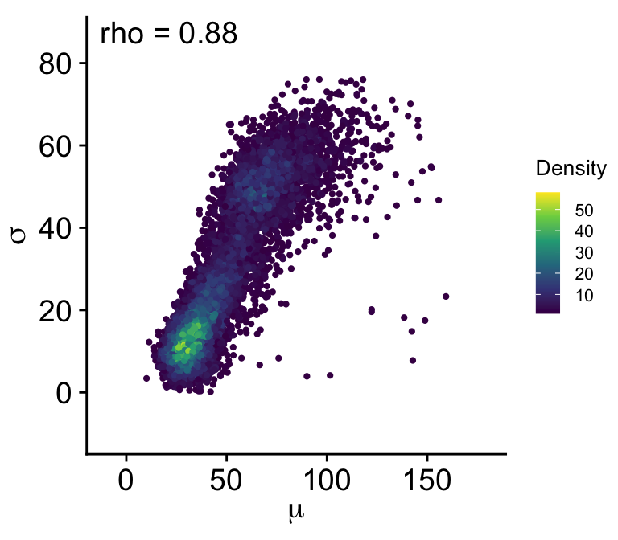

```r
plot_fkMean_vs_fkSD(cd4_rate_df)
```

# +1 Nucleosome Occupancy

The +1 nucleosome sits just downstream of the TSS and influences Pol II pausing. We use Micro-C 1D contact signal as a proxy for nucleosome occupancy and ask whether β predicts +1 nucleosome positioning.

We center a 2000 bp window around each TSS, extract the Micro-C signal from the 1D contact file, and apply a LOESS smooth (span = 0.05) to each row to reduce positional noise while preserving the +1 peak shape.

```r
# Human seqinfo required by ScoreMatrix for chromosome-level range validation
seqlevelsStyle(TxDb.Hsapiens.UCSC.hg38.knownGene) <- "Ensembl"
seqinfo_human <- seqinfo(TxDb.Hsapiens.UCSC.hg38.knownGene)

ns_matrix <- get_matrix_from_nucleosome_signal(cd4_rate, ns_signal_file, seqinfo_human)

# Attach rate metadata (betaGroup, sdGroup, chiGroup) to the matrix object
ns_matrix$rate_df <- cd4_rate@rates

# Relabel chi tertiles for display
ns_matrix$rate_df$chiGroup <- factor(
  ns_matrix$rate_df$chiGroup,
  levels = levels(ns_matrix$rate_df$chiGroup),
  labels = c("Low expression", "Medium expression", "High expression")
)
cat("Nucleosome matrix dimensions:", dim(ns_matrix$smooth), "\n")
```

```
## Nucleosome matrix dimensions: 7026 2000
```

## β groups stratified by expression level

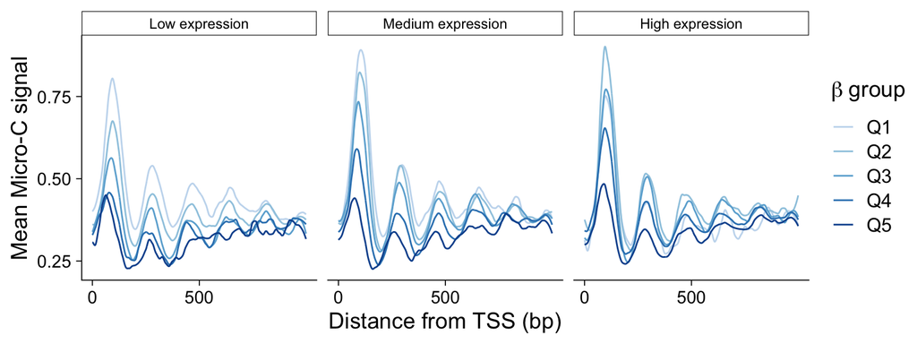

```r
make_microc_profile_plot(ns_matrix, group_col = "betaGroup", class_col = "chiGroup")
```

## σ groups (Sharp vs Broad) stratified by expression level

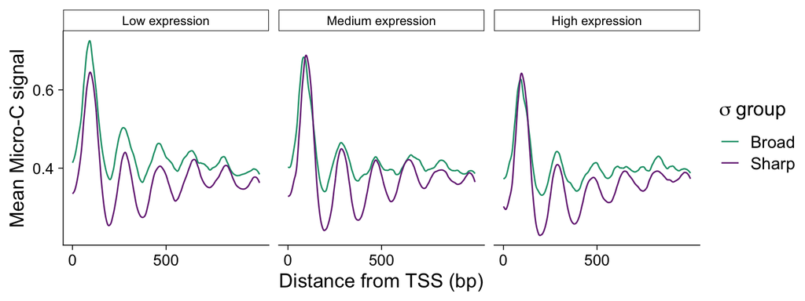

```r
sd_color <- c("#1b9e77", "#762a83")

make_microc_profile_plot(
  ns_matrix,
  group_col    = "sdGroup",
  class_col    = "chiGroup",
  colors       = sd_color,
  legend_title = expression(sigma ~ group)
)
```

# Histone Modifications

H3K4me3 marks active promoters and H3K27ac marks active regulatory elements. We use ENCODE ChIP-seq fold-change bigWig files for CD4+ T cells to ask whether β is associated with promoter histone modification levels, above and beyond what is explained by overall expression (χ).

For each gene we define a 500 bp window centered on its TSS and compute the mean ChIP-seq signal within that window.

```r
HISTONE_MARKS <- c("H3K4me3", "H3K27ac")
CHI_LABELS    <- c("Low expression", "Medium expression", "High expression")

# Load ENCODE metadata and update bigWig paths to the local data directory
meta_fc     <- readRDS(histone_meta_file)
meta_fc$bw  <- file.path(.paths$encode_bw, basename(meta_fc$bw))
meta_cd4    <- meta_fc %>%
  filter(Biosample == "CD4 regulatory", Target %in% HISTONE_MARKS)

# Build 500 bp promoter windows and overlap with H3K4me3 / H3K27ac bigWigs
promoter        <- get_promoter_df_from_stadyum_obj(cd4_rate, promoter_len = 500)
promoter$df     <- get_histone_modification_sum(promoter$df, promoter$grang, meta_cd4)
levels(promoter$df$chiGroup) <- CHI_LABELS
```

## β vs H3K4me3

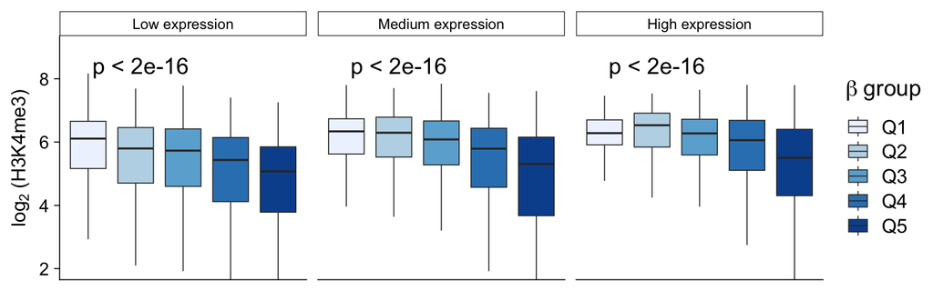

```r
plot_histone_boxplot(promoter$df, "H3K4me3", ylim = c(2, 9), label_x = 1.5)
```

## β vs H3K27ac

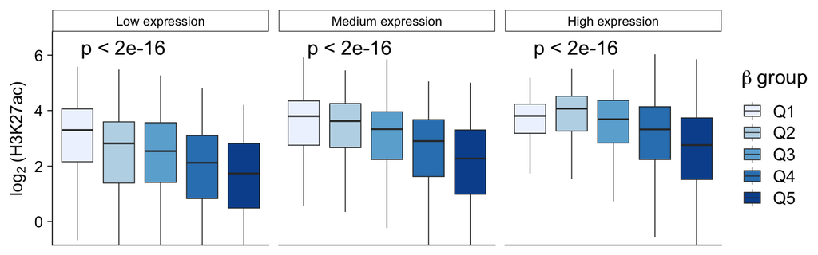

```r
plot_histone_boxplot(promoter$df, "H3K27ac", ylim = c(-0.5, 6.5), label_x = 1.5)
```

# Summary

This HTML report is designed to show the analysis and its figures inline in a single self-contained file. The full manuscript pipeline (scripts in `singleCellType/`) runs the same analyses for all species and cell types and saves publication-quality PDF figures separately.

**Downstream analyses** enabled by the saved `cd4_rate.RDS`:

- **Between-cell-type comparison**: pair CD4 and CD14 rate objects and apply a likelihood ratio test to identify genes with cell-type-specific changes in β or χ.
- **Between-species comparison**: align orthologous TSSs across primate species and test for evolutionary divergence in pause release kinetics.
- **Sequence feature integration**: link β or σ groups to core promoter motifs (TATA box, GC box, Initiator) or GC content to understand the sequence determinants of Pol II pausing.